# Exercise 5

Alicia Weber

13 February, 2025

# 1 Q1

```r
#file.choose()
dd <- read.csv("/Users/lish/Desktop/data_omics/prawnGR.CSV")
head(dd)
```

```
##     GRate    diet
## 1  9.7741 Natural
## 2 10.2931 Natural
## 3 10.0474 Natural
## 4 10.0808 Natural
## 5  9.3106 Natural
## 6 10.4414 Natural
```

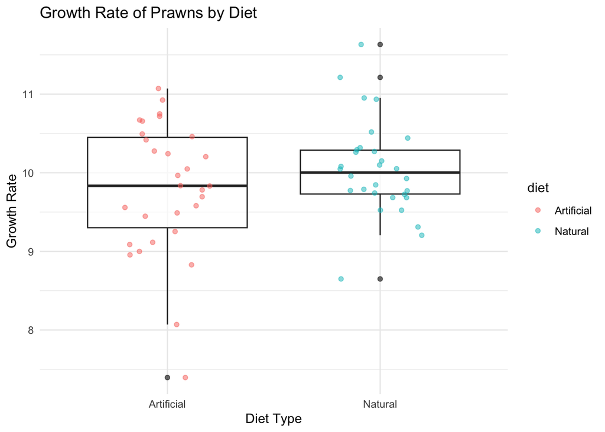

```r
ggplot(dd, aes(x=diet, y=GRate)) +
    geom_boxplot(alpha = 0.7) +
  geom_jitter(aes(color = diet), width = 0.2, alpha = 0.5) +  # Adds individual points
  theme_minimal() +
  labs(x = "Diet Type", y = "Growth Rate", title = "Growth Rate of Prawns by Diet")
```

```r
#observation nr diet type
dd %>%
  count(diet)
```

```
##         diet  n
## 1 Artificial 30
## 2    Natural 30
```

# 2 Q2

```r
#t-test
shapiro.test(dd$GRate[dd$diet == 'Natural'])
```

```
##
##  Shapiro-Wilk normality test
##
## data:  dd$GRate[dd$diet == "Natural"]
## W = 0.95985, p-value = 0.307
```

```r
shapiro.test(dd$GRate[dd$diet == 'Artificial'])
```

```
##
##  Shapiro-Wilk normality test
##
## data:  dd$GRate[dd$diet == "Artificial"]
## W = 0.94863, p-value = 0.1553
```

```r
#equal variances test
var.test(dd$GRate[dd$diet == 'Natural'], dd$GRate[dd$diet == 'Artificial'])
```

```
##
##  F test to compare two variances
##
## data:  dd$GRate[dd$diet == "Natural"] and dd$GRate[dd$diet == "Artificial"]
## F = 0.50946, num df = 29, denom df = 29, p-value = 0.07445
## alternative hypothesis: true ratio of variances is not equal to 1
## 95 percent confidence interval:
##  0.2424828 1.0703634
## sample estimates:
## ratio of variances
##          0.5094553
```

```r
#both seem normally distributed and variances appear equal
#could proceed with a student's t-test
```

# 3 Q3

```r
#could proceed with a student's t-test
# H0 = no significant difference in growth rates
t.test(dd$GRate ~ dd$diet, var.equal = TRUE)
```

```
##
##  Two Sample t-test
##
## data:  dd$GRate by dd$diet
## t = -1.3259, df = 58, p-value = 0.1901
## alternative hypothesis: true difference in means between group Artificial and group Natural is not equal to 0
## 95 percent confidence interval:
##  -0.6319362  0.1283495
## sample estimates:
## mean in group Artificial    mean in group Natural
##                 9.794133                10.045927
```

t-statistic = how many standard deviations the sample means are apart df = sample sizes and assumption of equal variances

# 4 Q4

```r
m1 <- lm(GRate ~ diet, data=dd)
summary(m1)
```

```
##
## Call:
## lm(formula = GRate ~ diet, data = dd)
##
## Residuals:
##      Min       1Q   Median       3Q      Max
## -2.39893 -0.35043  0.00337  0.45429  1.58577
##
## Coefficients:
##             Estimate Std. Error t value Pr(>|t|)
## (Intercept)   9.7941     0.1343  72.935   <2e-16 ***
## dietNatural   0.2518     0.1899   1.326     0.19
## ---
## Signif. codes:  0 '***' 0.001 '**' 0.01 '*' 0.05 '.' 0.1 ' ' 1
##
## Residual standard error: 0.7355 on 58 degrees of freedom
## Multiple R-squared:  0.02942,    Adjusted R-squared:  0.01268
## F-statistic: 1.758 on 1 and 58 DF,  p-value: 0.1901
```

# 5 Q5

```r
anova(m1)
```

```
## Analysis of Variance Table
##
## Response: GRate
##           Df Sum Sq Mean Sq F value Pr(>F)
## diet       1  0.951 0.95100  1.7579 0.1901
## Residuals 58 31.377 0.54098
```

comparing t-test and anova: - they are mathematically equivalent when comparing means of groups - p-values (0.1901) are therefore the same - df=1: one factor (diet) with two levels - df=58: 60 observations minus two parameters - F(1, 58) = 1.7579, p = 0.1901: no statistically significant difference in the mean growth rates -> diet type did not have a measurable impact

# 6 Q6

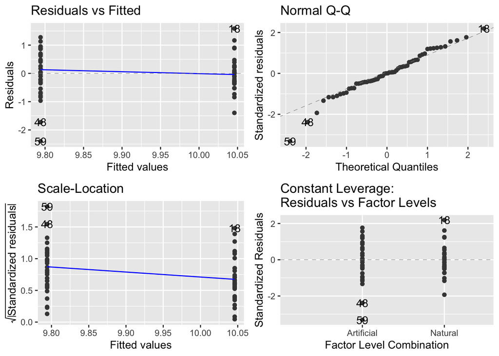

```r
autoplot(m1)
```

assumptions of normality, linearity, and equal variance are met, minor deviations in the Q-Q plot and a few potential outliers that likely don’t affect model validity

# 7 Q7

```r
#file.choose()
dd2 <- read.csv("/Users/lish/Desktop/data_omics/Gigartina.CSV")


# number replicates per diatom treatment
replics <- dd2 %>%
  count(diatom.treat)
print(replics)
```

```
##   diatom.treat  n
## 1         ASGM 10
## 2        Sdecl 10
## 3        Sexpo 10
## 4        Sstat 10
```

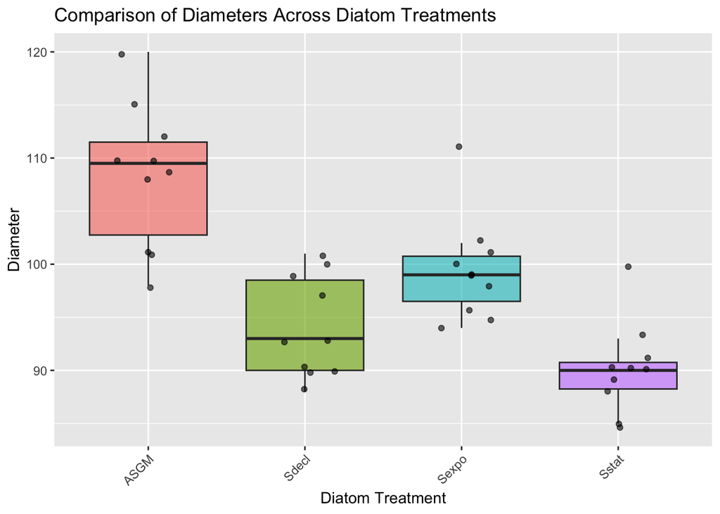

```r
# diameters across treatments
ggplot(dd2, aes(x = diatom.treat, y = diameter, fill = diatom.treat)) +
  geom_boxplot(alpha = 0.6, outlier.shape = NA) +
  geom_jitter(width = 0.2, alpha = 0.6) +
  labs(
    x = "Diatom Treatment",
    y = "Diameter",
    title = "Comparison of Diameters Across Diatom Treatments"
  ) +
  theme(axis.text.x = element_text(angle = 45, hjust = 1)) +
  guides(fill = "none")
```

# Q8, 9, 10

```r
m2 <- lm(diameter ~ diatom.treat, data=dd2)
summary(m2)
```

```
##
## Call:
## lm(formula = diameter ~ diatom.treat, data = dd2)
##
## Residuals:
##    Min     1Q Median     3Q    Max
## -10.40  -4.10  -0.25   2.60  11.60
##
## Coefficients:
##                   Estimate Std. Error t value Pr(>|t|)
## (Intercept)        108.400      1.659  65.345  < 2e-16 ***
## diatom.treatSdecl  -14.300      2.346  -6.095 5.18e-07 ***
## diatom.treatSexpo   -8.900      2.346  -3.794 0.000548 ***
## diatom.treatSstat  -18.300      2.346  -7.800 3.01e-09 ***
## ---
## Signif. codes:  0 '***' 0.001 '**' 0.01 '*' 0.05 '.' 0.1 ' ' 1
##
## Residual standard error: 5.246 on 36 degrees of freedom
## Multiple R-squared:  0.6549, Adjusted R-squared:  0.6262
## F-statistic: 22.78 on 3 and 36 DF,  p-value: 1.929e-08
```

```r
anova(m2)
```

```
## Analysis of Variance Table
##
## Response: diameter
##              Df Sum Sq Mean Sq F value    Pr(>F)
## diatom.treat  3 1880.3  626.76  22.775 1.929e-08 ***
## Residuals    36  990.7   27.52
## ---
## Signif. codes:  0 '***' 0.001 '**' 0.01 '*' 0.05 '.' 0.1 ' ' 1
```

H0 = There is no significant difference in the mean diameter of Metacarpus

- p=1.92e-08: at least one treatment group significantly different diam.
- Between groups (treatments): 3df
- Within groups (residuals): 36df

significant difference in the mean diameter of Metacarpus across the four treatment groups, F(3, 36) = 22.775, p < 0.001.

# 8 Q11

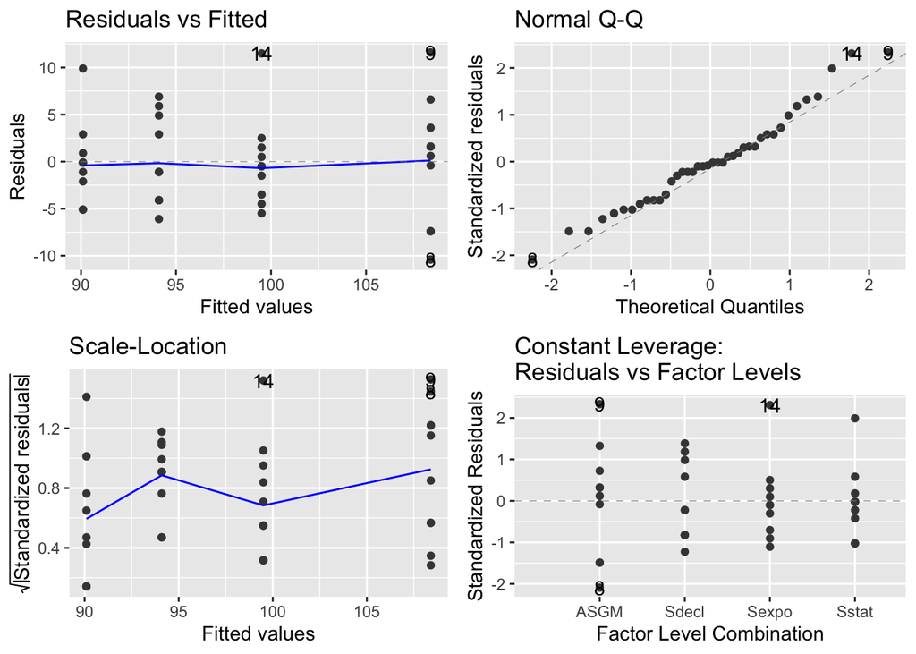

```r
autoplot(m2)
```

acceptable

# 9 Q12, 13, 14

```r
tukey <- TukeyHSD(aov(m2))
print(tukey)
```

```
##   Tukey multiple comparisons of means
##     95% family-wise confidence level
##
## Fit: aov(formula = m2)
##
## $diatom.treat
##              diff         lwr       upr     p adj
## Sdecl-ASGM  -14.3 -20.6184102  -7.98159 0.0000030
## Sexpo-ASGM   -8.9 -15.2184102  -2.58159 0.0029489
## Sstat-ASGM  -18.3 -24.6184102 -11.98159 0.0000000
## Sexpo-Sdecl   5.4  -0.9184102  11.71841 0.1165421
## Sstat-Sdecl  -4.0 -10.3184102   2.31841 0.3360087
## Sstat-Sexpo  -9.4 -15.7184102  -3.08159 0.0016145
```

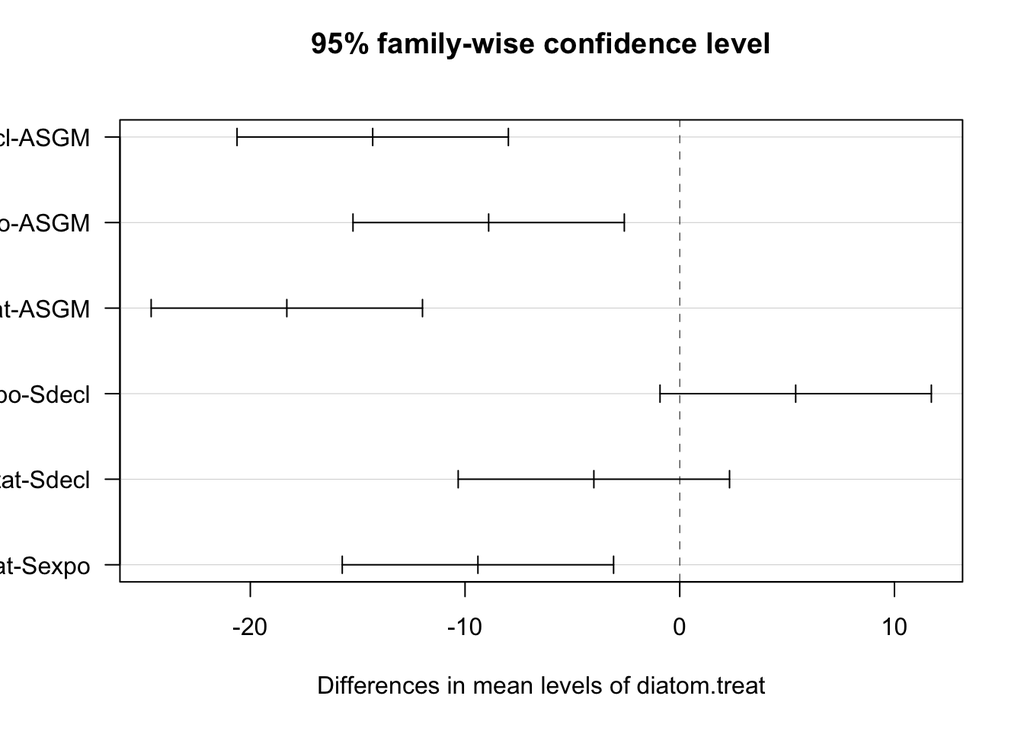

```r
plot(tukey, las = 1)
```

- ASGM differs from all treatments (p < 0.01).  
- Sstat differs from Sexpo (p = 0.0016).  
- No difference: Sexpo vs Sdecl, Sstat vs Sdecl (p > 0.05).  
- ASGM and Sstat show the largest differences.

# 10 Q15

```r
#file.choose()
dd3 <- read.csv("/Users/lish/Desktop/data_omics/TemoraBR.CSV")
str(dd3)
```

```
## 'data.frame':    45 obs. of  3 variables:
##  $ temp                : num  5 6 7 10 11 12 13 15 16 17 ...
##  $ beat_rate           : num  3.76 5.4 8 9.4 16.6 18.5 19 22.4 24.1 22.7 ...
##  $ acclimitisation_temp: int  5 5 5 5 5 5 5 5 5 5 ...
```

```r
summary(dd3)
```

```
##       temp         beat_rate      acclimitisation_temp
##  Min.   : 5.00   Min.   : 2.058   Min.   : 5.00
##  1st Qu.: 9.50   1st Qu.: 8.000   1st Qu.: 5.00
##  Median :15.00   Median :17.922   Median :10.00
##  Mean   :15.17   Mean   :18.439   Mean   :11.67
##  3rd Qu.:21.50   3rd Qu.:26.400   3rd Qu.:20.00
##  Max.   :25.50   Max.   :42.728   Max.   :20.00
```

```r
colnames(dd3)
```

```
## [1] "temp"                 "beat_rate"            "acclimitisation_temp"
```

```r
ncol(dd3) #nr variables
```

```
## [1] 3
```

```r
nrow(dd3) #nr observations
```

```
## [1] 45
```

dependent: beat rate explanatory: temp

# 11 Q16

```r
dd3$Facclimatisation_temp <- as_factor(dd3$acclimitisation_temp)
str(dd3)
```

```
## 'data.frame':    45 obs. of  4 variables:
##  $ temp                 : num  5 6 7 10 11 12 13 15 16 17 ...
##  $ beat_rate            : num  3.76 5.4 8 9.4 16.6 18.5 19 22.4 24.1 22.7 ...
##  $ acclimitisation_temp : int  5 5 5 5 5 5 5 5 5 5 ...
##  $ Facclimatisation_temp: Factor w/ 3 levels "5","10","20": 1 1 1 1 1 1 1 1 1 1 ...
```

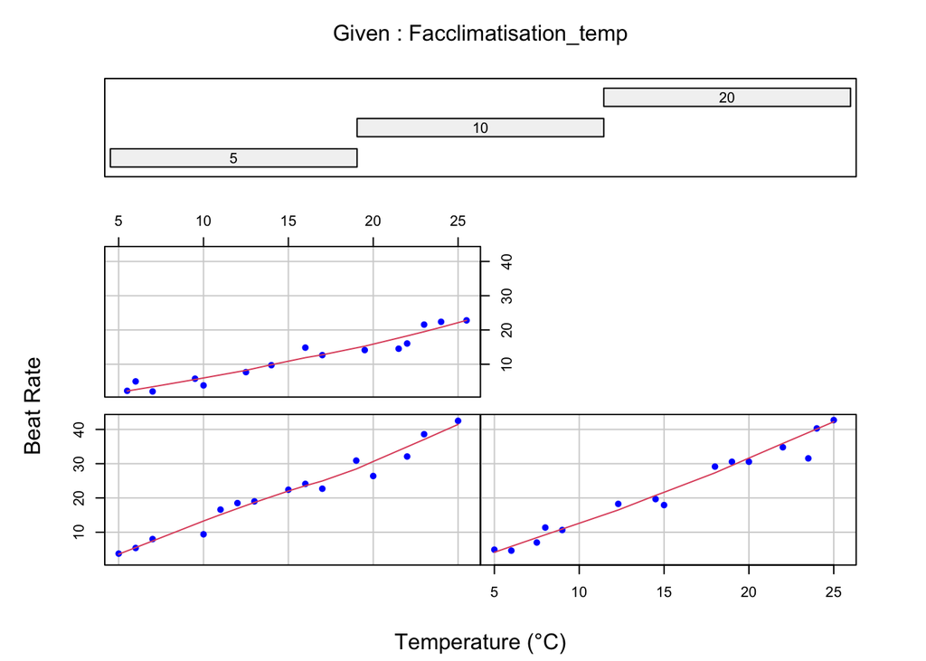

```r
#coplot
coplot(beat_rate ~ temp | Facclimatisation_temp,
       data = dd3,
       panel = panel.smooth,
       xlab = "Temperature (°C)",
       ylab = "Beat Rate",
       col = "blue",
       pch = 16)
```

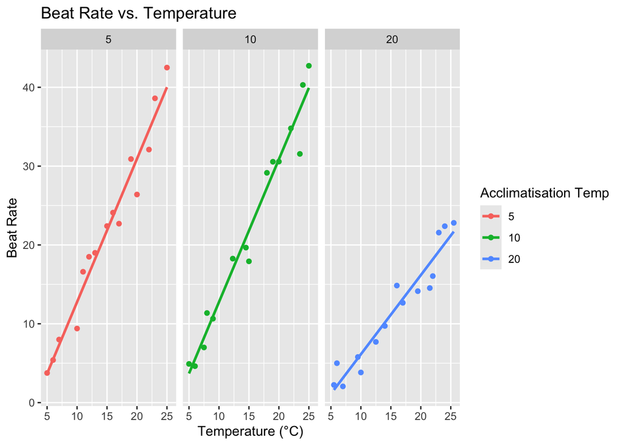

```r
#ggplot
ggplot(dd3, aes(x = temp, y = beat_rate, color = Facclimatisation_temp)) +
  geom_point() +
  geom_smooth(method = "lm", se = FALSE) +
  facet_wrap(~ Facclimatisation_temp) +
  labs(title = "Beat Rate vs. Temperature",
       x = "Temperature (°C)",
       y = "Beat Rate",
       color = "Acclimatisation Temp")
```

rate of increase in beat rate with temp appears steeper in 5,10 than in 20: suggests acclimatisation temp influences intercept and also rate at which beat rate changes with temperature.

# 12 Q17, 18, 19

```r
#slopes were not parallel, interaction term!
m4 <- lm(beat_rate ~ temp * Facclimatisation_temp, data = dd3)
summary(m4)
```

```
##
## Call:
## lm(formula = beat_rate ~ temp * Facclimatisation_temp, data = dd3)
##
## Residuals:
##     Min      1Q  Median      3Q     Max
## -5.6600 -1.2269  0.2993  1.9053  2.8827
##
## Coefficients:
##                               Estimate Std. Error t value Pr(>|t|)
## (Intercept)                  -5.412643   1.531198  -3.535  0.00107 **
## temp                          1.816967   0.096038  18.919  < 2e-16 ***
## Facclimatisation_temp10       0.050312   2.107559   0.024  0.98108
## Facclimatisation_temp20       1.509699   2.133111   0.708  0.48331
## temp:Facclimatisation_temp10 -0.005408   0.129481  -0.042  0.96690
## temp:Facclimatisation_temp20 -0.813208   0.130173  -6.247 2.35e-07 ***
## ---
## Signif. codes:  0 '***' 0.001 '**' 0.01 '*' 0.05 '.' 0.1 ' ' 1
##
## Residual standard error: 2.266 on 39 degrees of freedom
## Multiple R-squared:  0.9665, Adjusted R-squared:  0.9622
## F-statistic: 224.9 on 5 and 39 DF,  p-value: < 2.2e-16
```

```r
anova(m4)
```

```
## Analysis of Variance Table
##
## Response: beat_rate
##                            Df Sum Sq Mean Sq F value    Pr(>F)
## temp                        1 4293.7  4293.7 835.866 < 2.2e-16 ***
## Facclimatisation_temp       2 1197.7   598.8 116.576 < 2.2e-16 ***
## temp:Facclimatisation_temp  2  284.1   142.0  27.651 3.331e-08 ***
## Residuals                  39  200.3     5.1
## ---
## Signif. codes:  0 '***' 0.001 '**' 0.01 '*' 0.05 '.' 0.1 ' ' 1
```

- effect of temperature on beat_rate varies depending on the acclimatisation temperature
- acclimatisation temperature modifies the effect of temperature on beat rate
- explains why lines in facet plot not parallel
- main effects should not be interpreted in isolation

-> we could run separate models for each acclimatisation temperature

# 13 Q20

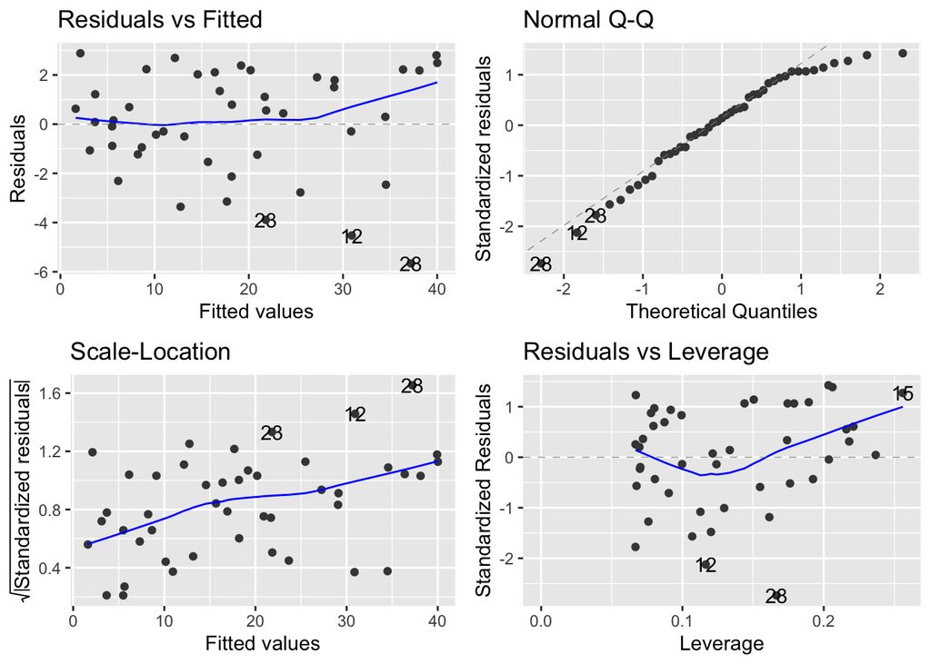

```r
autoplot(m4)
```

- no major violations regression assumptions - slight heteroscedasticity at higher fitted values - minor non-normality - no strong outliers

# 14 Q21

- Linear model with interaction term tested effects of temp and Facclimatisation_temp on beat_rate
- Significant interaction( p < 0.001) -> Effect of temp on beat rate varies by acclimatisation temp
- Main effects significant (p < 0.001) but not interpretable alone due to interaction
- High model fit (Adjusted R² = 0.9622)
- Residual diagnostics: slight heteroscedasticity, no major violations
- Beat rate increases with temp, but rate of increase depends on acclimatisation temp
- Next step: Separate regressions for each acclimatisation group may be necessary

# 15 Session Information

**R version 4.4.1 (2024-06-14)**

**Platform:** aarch64-apple-darwin20

**locale:** en_US.UTF-8||en_US.UTF-8||en_US.UTF-8||C||en_US.UTF-8||en_US.UTF-8

**attached base packages:** *stats*, *graphics*, *grDevices*, *utils*, *datasets*, *methods* and *base*

**other attached packages:** *ggfortify(v.0.4.17)*, *lubridate(v.1.9.3)*, *forcats(v.1.0.0)*, *stringr(v.1.5.1)*, *dplyr(v.1.1.4)*, *purrr(v.1.0.2)*, *tidyr(v.1.3.1)*, *tibble(v.3.2.1)*, *ggplot2(v.3.5.1)*, *tidyverse(v.2.0.0)* and *readr(v.2.1.5)*

**loaded via a namespace (and not attached):** *sass(v.0.4.9)*, *utf8(v.1.2.4)*, *generics(v.0.1.3)*, *lattice(v.0.22-6)*, *stringi(v.1.8.4)*, *hms(v.1.1.3)*, *digest(v.0.6.37)*, *magrittr(v.2.0.3)*, *evaluate(v.1.0.1)*, *grid(v.4.4.1)*, *timechange(v.0.3.0)*, *bookdown(v.0.42)*, *fastmap(v.1.2.0)*, *Matrix(v.1.7-0)*, *jsonlite(v.1.8.9)*, *gridExtra(v.2.3)*, *mgcv(v.1.9-1)*, *pander(v.0.6.5)*, *fansi(v.1.0.6)*, *scales(v.1.3.0)*, *jquerylib(v.0.1.4)*, *cli(v.3.6.3)*, *rlang(v.1.1.4)*, *splines(v.4.4.1)*, *munsell(v.0.5.1)*, *withr(v.3.0.2)*, *cachem(v.1.1.0)*, *yaml(v.2.3.10)*, *tools(v.4.4.1)*, *tzdb(v.0.4.0)*, *colorspace(v.2.1-1)*, *vctrs(v.0.6.5)*, *R6(v.2.5.1)*, *lifecycle(v.1.0.4)*, *pkgconfig(v.2.0.3)*, *pillar(v.1.9.0)*, *bslib(v.0.8.0)*, *gtable(v.0.3.6)*, *Rcpp(v.1.0.13)*, *glue(v.1.8.0)*, *xfun(v.0.48)*, *tidyselect(v.1.2.1)*, *highr(v.0.11)*, *rstudioapi(v.0.17.1)*, *knitr(v.1.48)*, *farver(v.2.1.2)*, *nlme(v.3.1-164)*, *htmltools(v.0.5.8.1)*, *rmarkdown(v.2.28)*, *labeling(v.0.4.3)* and *compiler(v.4.4.1)*